# Mestrado Biologia

Herson Melo

28/06/2018

## Análise do Jogo de Imagens aplicadas no Ensino médio

Roteiro de análise:

### Amostra dos dados da pesquisa realizada

Tabulação do número de acertos dos itens do jogo de imagens.

| Coluna | Descrição |
| --- | --- |
| Exoticas | Número de acertos dentre todas as imagens exibidas do tipo exótica, valor experado é 5. |
| Nativas | Número de acertos dentre todas as imagens exibidas do tipo nativa, valor experado é 5. |

```r
head(pos_gabarito$dados, 10)
```

| codigo | municipio | escola | modelo | turmas | sexo | idade | temp.residencia | area | bairro | nome.escola | frequencia | fez.aula | flona | exoticas | nativas | origem_exoticas | origem_nativas | indice_exoticas | indice_nativas | exotica_aves | exotica_invertebrado | exotica_mamifero | exotica_peixe | exotica_reptil | nativa_aves | nativa_invertebrado | nativa_mamifero | nativa_peixe | nativa_reptil |
| --- | --- | --- | --- | --- | --- | --- | --- | --- | --- | --- | --- | --- | --- | --- | --- | --- | --- | --- | --- | --- | --- | --- | --- | --- | --- | --- | --- | --- | --- |
| 1 | Silvânia | Particular | 1 | 1 | Feminino | 17 |  | Urbana |  | Ginásio Anchieta | Ás vezes | Sim | Não | 5 | 3 | 3 | 4 | 3 | 3 | 1 | 1 | 1 | 1 | 1 | 1 | 0 | 1 | 0 | 1 |
| 2 | Silvânia | Particular | 1 | 1 | Feminino | 17 | 17 | Urbana | pedrinhas | Ginásio Anchieta | Ás vezes | Sim | Sim | 4 | 5 | 4 | 5 | 4 | 5 | 1 | 1 | 1 | 1 | 0 | 1 | 1 | 1 | 1 | 1 |
| 3 | Silvânia | Particular | 1 | 1 | Masculino | 17 | 17 | Urbana | são sebastião 7 | Ginásio Anchieta | Frequentemente | Sim | Sim | 4 | 5 | 4 | 5 | 4 | 5 | 1 | 1 | 1 | 1 | 0 | 1 | 1 | 1 | 1 | 1 |
| 4 | Silvânia | Particular | 1 | 1 | Masculino | 17 | 17 | Urbana | parque anchieta | Ginásio Anchieta | Frequentemente | Não | Não | 5 | 3 | 3 | 4 | 3 | 3 | 1 | 1 | 1 | 1 | 1 | 1 | 0 | 1 | 0 | 1 |
| 5 | Silvânia | Particular | 2 | 1 | Feminino | 17 | 17 | Rural | centro | Ginásio Anchieta | Frequentemente | Não | Não | 5 | 3 | 0 | 5 | 0 | 3 | 1 | 1 | 1 | 1 | 1 | 1 | 1 | 1 | 0 | 0 |
| 6 | Silvânia | Particular | 2 | 1 | Feminino | 17 | 15 | Rural |  | Ginásio Anchieta | Sempre | Sim | Não | 3 | 3 | 2 | 4 | 1 | 3 | 1 | 0 | 1 | 0 | 1 | 1 | 1 | 0 | 1 | 0 |
| 7 | Silvânia | Particular | 2 | 1 | Masculino | 18 | 3 | Urbana | res. anhanguera | Ginásio Anchieta | Sempre | Não | Não | 3 | 3 | 2 | 5 | 1 | 3 | 1 | 1 | 1 | 0 | 0 | 1 | 1 | 0 | 1 | 0 |
| 8 | Silvânia | Particular | 3 | 1 | Feminino | 16 | 8 | Rural |  | Ginásio Anchieta | Sempre | Não | Sim | 2 | 3 | 2 | 4 | 1 | 3 | 0 | 0 | 0 | 1 | 1 | 1 | 1 | 1 | 0 | 0 |
| 9 | Silvânia | Particular | 3 | 1 | Masculino | 16 |  | Urbana | anhanguera | Ginásio Anchieta | Ás vezes | Não | Sim | 3 | 3 | 2 | 3 | 2 | 2 | 0 | 0 | 1 | 1 | 1 | 0 | 1 | 1 | 1 | 0 |
| 10 | Silvânia | Particular | 3 | 1 | Feminino | 17 | 17 | Urbana | Leonides cotrim | Ginásio Anchieta | Frequentemente | Sim | Não | 4 | 4 | 3 | 3 | 2 | 2 | 1 | 0 | 1 | 1 | 1 | 1 | 1 | 1 | 1 | 0 |

#### Determinado a taxa de percepção

Entende-se por taxa de percepção o fator determinado pela quantidade média de acertos dentre as questões apresentadas aos alunos, em relação a turma em que o questionario foi aplicado.

```r
print(pos_gabarito$proporcoes$por_turma)
```

| turmas | qtde | total_acertos_esperado | p_exoticas | p_nativas | p_origem_exoticas | p_origem_nativas | p_indice_exoticas | p_indice_nativas |
| --- | --- | --- | --- | --- | --- | --- | --- | --- |
| 1 | 14 | 70 | 0.7714 | 0.6143 | 0.5000 | 0.8000 | 0.4286 | 0.5429 |
| 2 | 18 | 90 | 0.7000 | 0.7889 | 0.5889 | 0.8000 | 0.4556 | 0.7444 |
| 3 | 18 | 90 | 0.7111 | 0.7111 | 0.4333 | 0.8444 | 0.3333 | 0.6222 |
| 4 | 18 | 90 | 0.6556 | 0.7556 | 0.4333 | 0.8000 | 0.3333 | 0.6222 |
| 5 | 16 | 80 | 0.9375 | 0.4875 | 0.6250 | 0.8750 | 0.5875 | 0.4000 |
| 6 | 27 | 135 | 0.7407 | 0.7111 | 0.5852 | 0.8222 | 0.5259 | 0.6519 |
| 7 | 21 | 105 | 0.8667 | 0.5905 | 0.7143 | 0.7714 | 0.6286 | 0.4667 |
| 8 | 27 | 135 | 0.6296 | 0.7407 | 0.3556 | 0.7259 | 0.2963 | 0.5704 |
| 9 | 23 | 115 | 0.8435 | 0.4174 | 0.5739 | 0.8609 | 0.5217 | 0.3652 |
| 10 | 22 | 110 | 0.8182 | 0.7455 | 0.5818 | 0.8545 | 0.5182 | 0.6727 |

[output cut: 7 more lines]

### Teste de normalidade

Para determinar a normalidade nas distribuiçoes das respostas do jogo de imagens.

#### Identificação médio das turmas (nomes das espécies & origens)

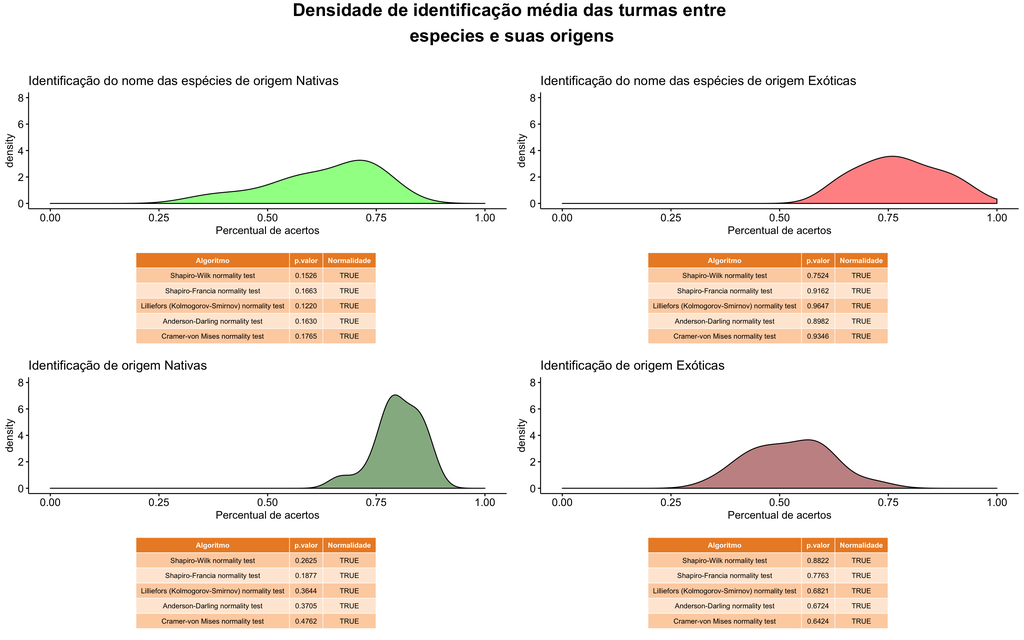

#### Indice de reconhecimento médio das turmas

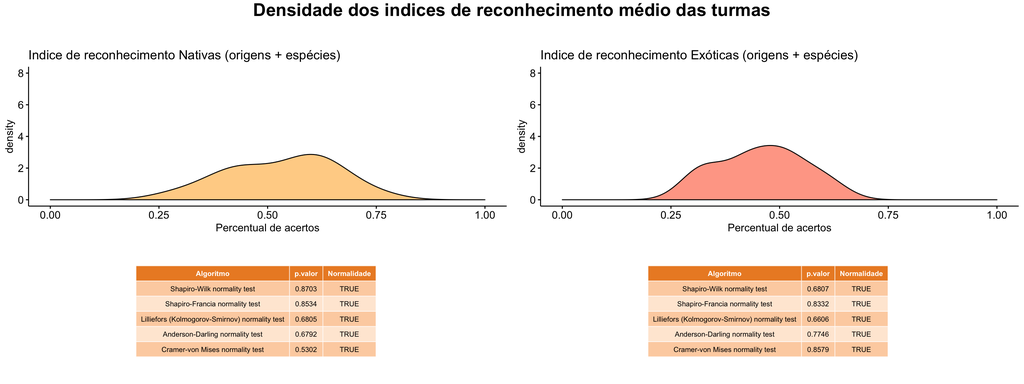

### Q-Q Test

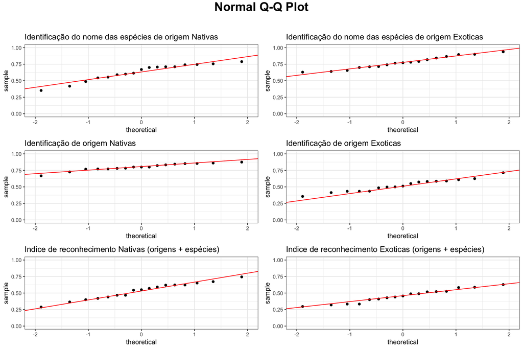

### Teste de variância

Para determinar a variância

| Algoritmo | Comparação | Variável | p_valor | variancia |
| --- | --- | --- | --- | --- |
| F test to compare two variances | Nativas x Exóticas | Indice de reconhecimento | 0.4036 | TRUE |
|  |  | Identificação do nome das espécies | 0.2551 | TRUE |
|  |  | Identificação da origem | 0.0343 | FALSE |

### Analises descritivas

```r
head(pos_gabarito$especies, 10)
```

| origem | grupo | especie | especieDesc | modelo | tot.modelo | qtde.acertos | fr |
| --- | --- | --- | --- | --- | --- | --- | --- |
| Nativo | Mamifero | tamandua-bandeira | tamandua-bandeira | 1 | 97 | 93 | 0.9588 |
| Exótico | Réptil | cobra-naja | cobra-naja | 3 | 87 | 79 | 0.9080 |
| Exótico | Mamifero | ornitorrinco | ornitorrinco | 4 | 96 | 85 | 0.8854 |
| Nativo | Ave | seriema | seriema | 1 | 97 | 81 | 0.8351 |
| Exótico | Mamifero | coala | coala | 1 | 97 | 79 | 0.8144 |
| Exótico | Peixe | peixe-japones | peixe-japones | 1 | 97 | 74 | 0.7629 |
| Nativo | Peixe | lambari | lambari | 1 | 97 | 71 | 0.7320 |
| Nativo | Ave | coruja-buraqueira | coruja-buraqueira | 3 | 87 | 63 | 0.7241 |
| Nativo | Mamifero | macaco-prego | macaco-prego | 3 | 87 | 63 | 0.7241 |
| Nativo | Mamifero | lobo-guara | lobo-guara | 2 | 87 | 62 | 0.7126 |

#### Indice de identificação por Origem

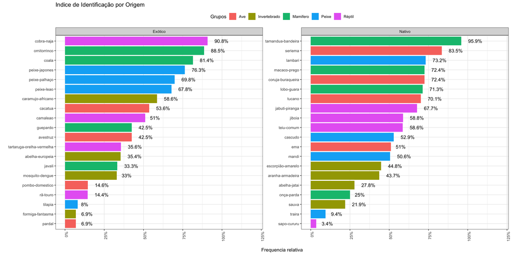

#### Indice de identificação por Espécie

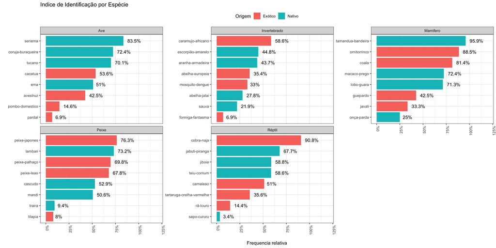

### Testes de hipoteses

Esperado p-valor >= 0.05 na normalidade (espera-se H0) Esperado p-valor <= 0.05 no teste de hipotese (espera-se H1)

1. Os alunos itendificam mais os nomes dos animais de espécies exóticas que os animais de espécies nativas.

**TEST T-student**  
H0 = Tident(exoticas) = Tident(nativas)  
H1 = Tident(exoticas) > Tident(nativas)

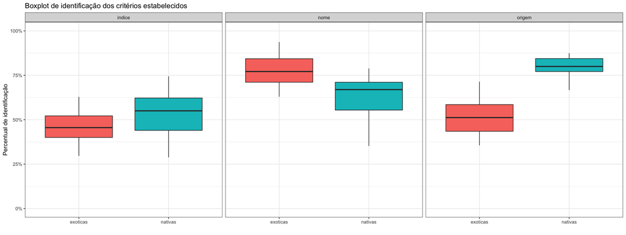

| Algoritmo | Comparação | Variável | p_valor | H0 | H1 | Confiança |
| --- | --- | --- | --- | --- | --- | --- |
| Two Sample t-test | Nativas x Exóticas | Indice de reconhecimento | 0.0602 | TRUE | FALSE | -0.34% ~ 15.33% |
|  |  | Identificação do nome das espécies | 0.0006 | FALSE | TRUE | -22.28% ~ -6.83% |
|  |  | Identificação da origem | 0 | FALSE | TRUE | 22.49% ~ 33% |

Obs.: Intervalo de confiança 95%

```r
## Hipotese 1
# t.test(jogo.dados.em.p$p_nativas, jogo.dados.em.p$p_exoticas,
#        alternative = "two.sided", paired = F, var.equal = T)
```

2. Os alunos identificam mais espécies de origem exótica que as de origem nativa.

**TEST T-student**  
H0 = Tident(origem.exoticas) = Tident(origem.nativas)  
H1 = Tident(origem.exoticas) > Tident(origem.nativas)

```r
## Hipotese 2
t.test(pos_gabarito$proporcoes$por_turma$p_origem_nativas,
       pos_gabarito$proporcoes$por_turma$p_origem_exoticas,
       alternative = "two.sided", paired = F, var.equal = T)
```

```
    Two Sample t-test

data:  pos_gabarito$proporcoes$por_turma$p_origem_nativas and pos_gabarito$proporcoes$por_turma$p_origem_exoticas
t = 11, df = 32, p-value = 0.000000000004
alternative hypothesis: true difference in means is not equal to 0
95 percent confidence interval:
 0.2249 0.3300
sample estimates:
mean of x mean of y
   0.8005    0.5231
```

3. Os alunos identificam mais as espécies exóticas (nome dos animais e origem) que espécies nativas.

**ANOVA**

```r
# t.test(jogo.dados.em.p$p_nativas, jogo.dados.em.p$p_origem_nativas,
#        alternative = "two.sided", paired = F, var.equal = T)
# t.anova <- aov(g2$proporcao ~ g2$especie + g2$tipo)
# summary(t.anova)
```

4. Os alunos reconhecem mais mamíferos do que os demais grupos taxonómicos.

**ANOVA**

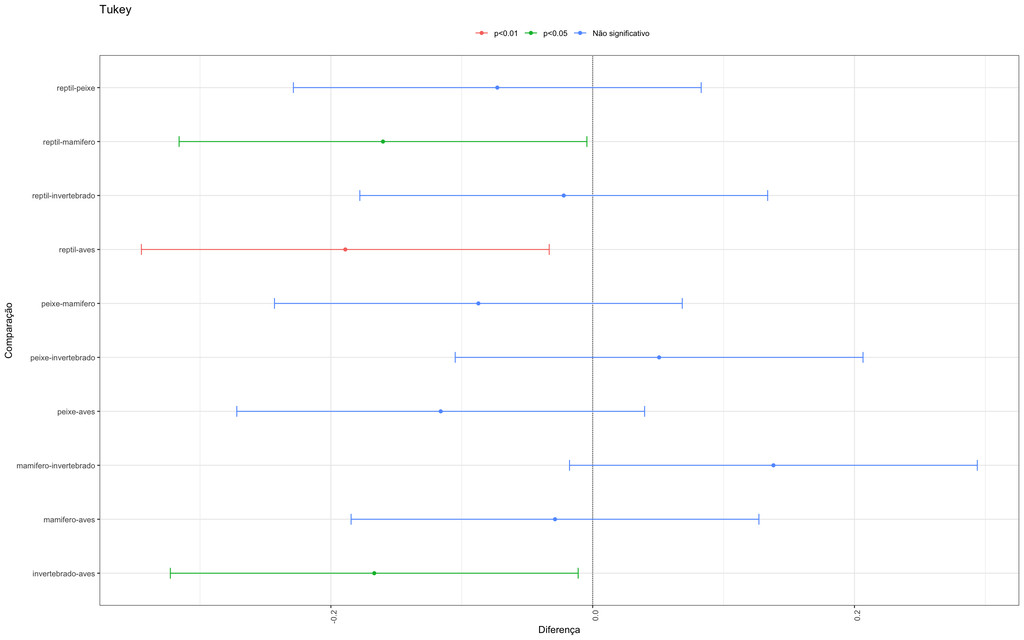

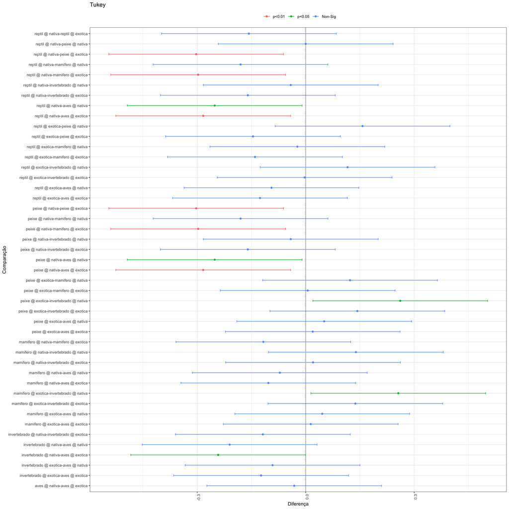

```r
## Hipotese 4
# t.test(jogo.dados.em.p$p_exoticas, jogo.dados.em.p$p_origem_exoticas,
#        alternative = "two.sided", paired = F, var.equal = T)
```

6. Estudantes que residem na Cidade 1 (com UC) identificam mais espécies nativas do que estudantes que residem na Cidade 2 (sem UC).

```r
t.test(nat_silvania, nat_belavista,
       alternative = "two.sided", paired = F, var.equal = T)
```

```
    Two Sample t-test

data:  nat_silvania and nat_belavista
t = 0.6, df = 15, p-value = 0.6
alternative hypothesis: true difference in means is not equal to 0
95 percent confidence interval:
 -0.09486  0.16984
sample estimates:
mean of x mean of y
   0.6463    0.6089
```